# Lecture 02: Fits and residuals

S470/670

Spring 2017

**READ: Cleveland pp. 34–41.**

Load our standard libraries:

```r
library(lattice)
library(ggplot2)
```

### Aggregation and dot plots

Last time we decided that the singer heights for each vocal part were well-approximated by normal distributions. Now we ask: What are the parameters of those distributions? Firstly, what are the mean heights for Soprano 1s, Soprano 2s, etc.? As you learned a long time ago, the “best” estimate of the population mean is the sample mean. We can use the `aggregate()` function to easily find the sample mean for each voice part.

```r
singer.means = aggregate(height~voice.part, FUN=mean, data=singer)
```

We now have one number for each of a set of categories. While this kind of data is traditionally displayed using a bar graph, a **dot plot** is arguably preferable, because they use position and not area to represent numbers. This is good because (i) humans are better at judging position than area, and (ii) for positions you don’t have to start your axis at zero, while for areas you do. The `ggplot` function is `geom_point()`:

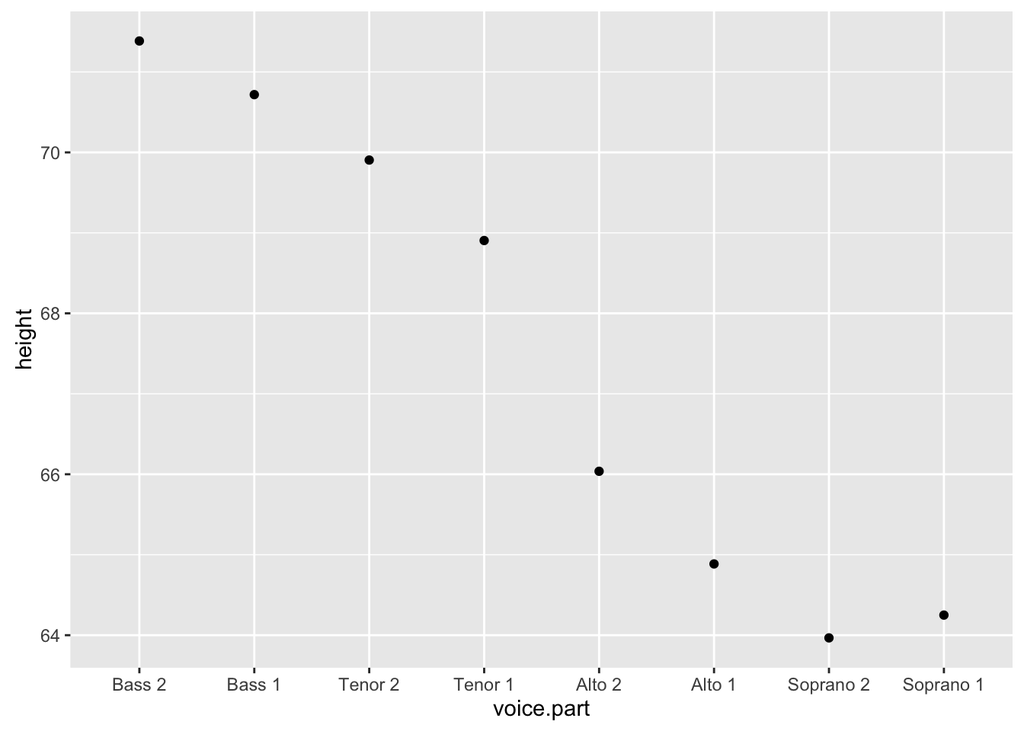

```r
ggplot(singer.means, aes(x=voice.part, y=height)) +
  geom_point()
```

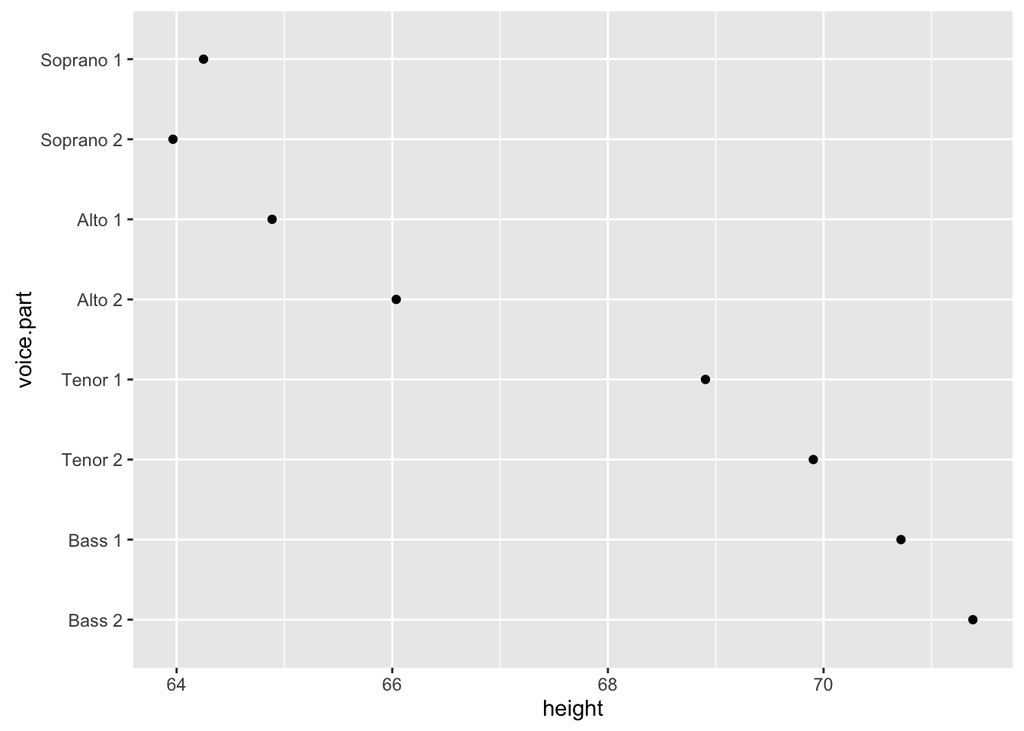

```r
ggplot(singer.means, aes(x=height, y=voice.part)) +
  geom_point()
```

### Models and residuals

We now have a simple model for singer heights.

Singer height = Average height for their voice part + some error

If you’ve taken S431/631 or a similar regression course, you might recognize this as a special case of a linear model. If you haven’t, well, it doesn’t really matter much except we can use the `lm()` function to fit the model. The advantage of this is that `lm()` easily splits the data into **fitted values** and **residuals**:

Observed value = Fitted value + residual

Here the fitted values are just the sample averages for each voice part.

```r
singer.lm = lm(height ~ voice.part, data=singer)
```

We can extract the fitted values using `fitted.values(singer.lm)` and the residuals with `residuals(singer.lm)` or `singer.lm$residuals`. For convenience, we create a data frame with two columns: the voice parts and the residuals.

```r
singer.res = data.frame(voice.part=singer$voice.part, residual=residuals(singer.lm))
```

There are a few ways we can look at the residuals. Side-by-side boxplots give a broad overview:

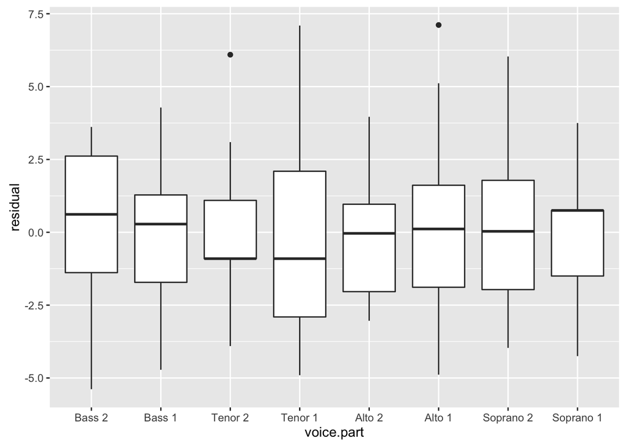

```r
ggplot(singer.res, aes(x=voice.part, y=residual)) + geom_boxplot()
```

We also want to examine normality of the residuals, broken up by voice part. We do this by faceting:

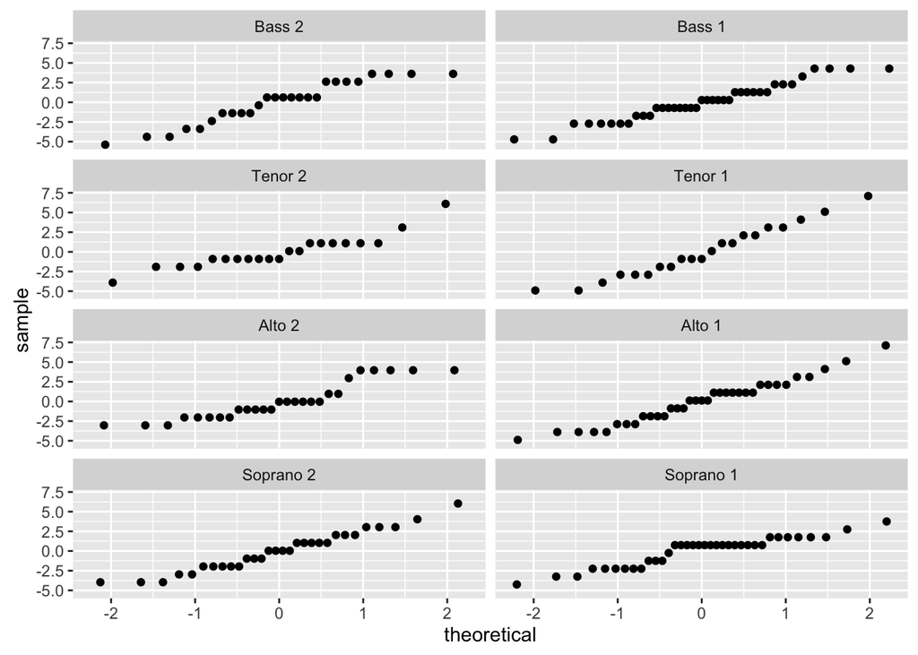

```r
ggplot(singer.res, aes(sample = residual)) +
  stat_qq() + facet_wrap(~voice.part, ncol=2)
```

Not only do the lines look reasonably straight, the scales look similar for all eight voice parts. This suggests a model where all of the errors are normal with the *same* standard deviation. We propose this model:

Singer height = Average height for their voice part + Normal($0, \sigma^2$) error.

To see if this is a good fit, we **pool** the residuals and plot them. First let’s try an ECDF plot:

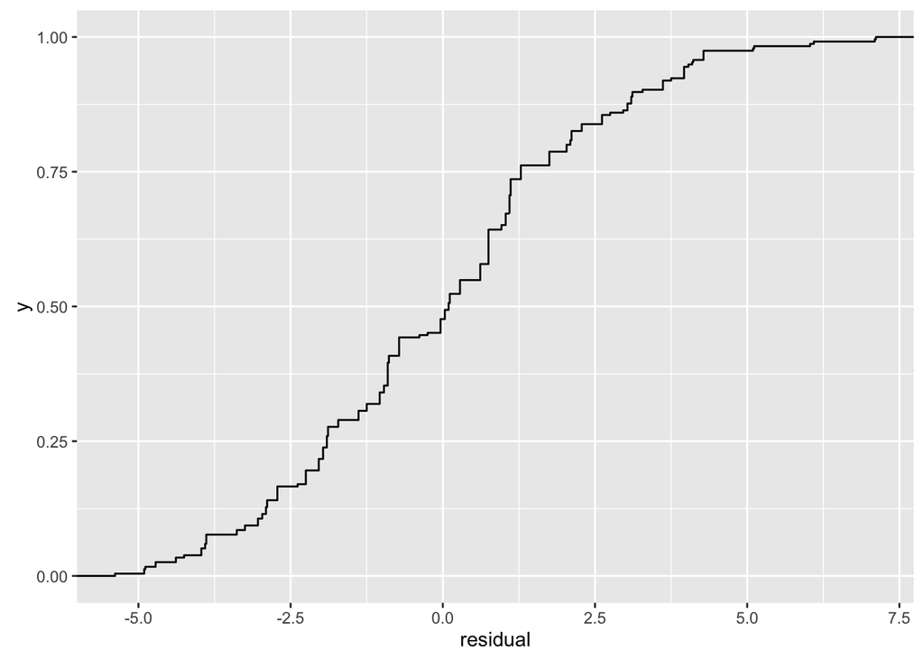

```r
ggplot(singer.res, aes(x = residual)) +
  stat_ecdf()
```

A normal distribution would give this S-shape, but so would many other distributions. To check normality directly, as usual we draw a normal QQ plot.

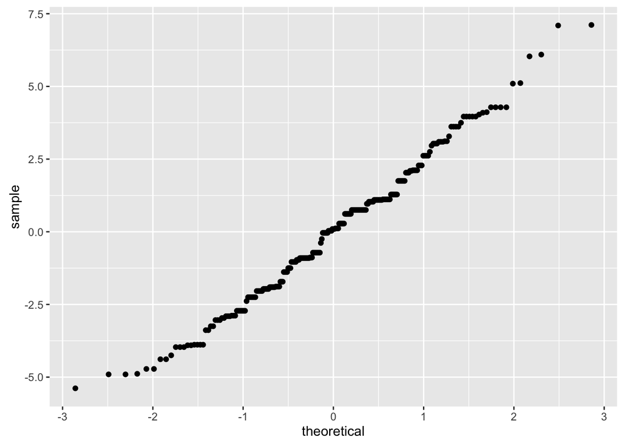

```r
ggplot(singer.res, aes(sample = residual)) +
  stat_qq()
```

We’ll also add a line with the mean of the residuals (which should be zero) as the intercept, and the SD of the residuals as the slope.

```r
round(mean(singer.res$residual), 3)
```

```
## [1] 0
```

```r
round(sd(singer.res$residual), 3)
```

```
## [1] 2.465
```

Pedantic note: We should use an $n-8$ denominator instead of $n-1$ in the SD calculation for degrees of freedom reasons. We can get this directly from the linear model:

```r
round(summary(singer.lm)$sigma, 3)
```

```
## [1] 2.503
```

However, the difference between this and the SD above is negligible.

Add the line:

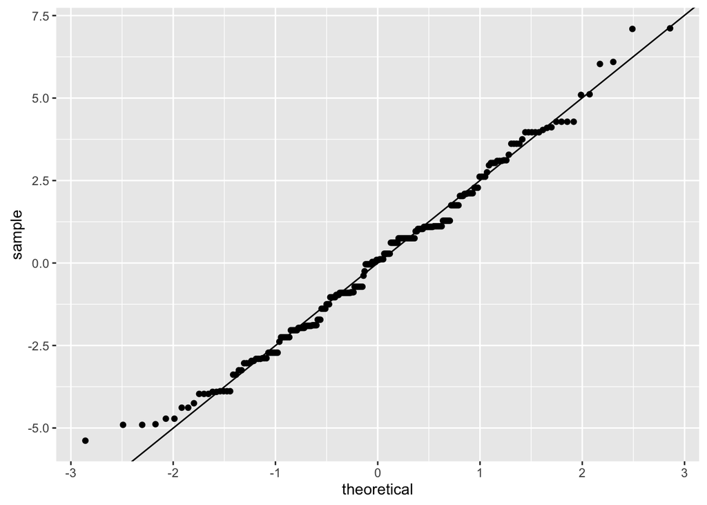

```r
ggplot(singer.res, aes(sample = residual)) +
  stat_qq() + geom_abline(intercept=0, slope=summary(singer.lm)$sigma)
```

The straight line isn’t absolutely perfect, but it’s doing a pretty good job. Our model is thus

Singer height = Average height for their voice part + Normal($0, 2.5^2$) error.

### Residual-fit spread

A useful thing to do (moreso when the predictor is continuous, but still useful here) is to visually compare the spread of the fitted values with the spread of the residuals. This gives an intuitive idea of how much variation is captured by the model fit and how much remains in the residuals. To do this, we want to draw two panels next to each other on the same scale: a uniform QQ plot of the fitted values (after subtracting the overall mean) and a uniform QQ plot of the residuals. We’ll do this fairly manually. The first goal is to get the fitted values and the residuals, and separately sort them:

```r
singer.fitted = sort(fitted.values(singer.lm)) - mean(fitted.values(singer.lm))
singer.residuals = sort(residuals(singer.lm))
```

Now we calculate the $f$-values (there’s only one set, since there’s the same number of fitted values and residuals) and stick everything into a data frame.

```r
n = length(singer.residuals)
f.value = (0.5:(n - 0.5)) / n
singer.fit = data.frame(f.value, Fitted=singer.fitted, Residuals=singer.residuals)
```

We now have a problem: We have a data frame with 235 observations in three columns:

f.value, Fitted, Residuals

But to use faceting in `ggplot`, we’d like a data frame with (2 $\times$ 235) observations in these three columns:

f.value, type, value

where “type” is a categorical variable (either “Fitted” or “Residual”) and “value” is the numerical value (either the fitted value or the residual.)

We could easily manually hammer the data into the right form, but instead we’ll learn a new tool to do this.

### gather(): A lifesaver

We’ll use `gather()` in Hadley Wickham’s `tidyr` library, which has saved the lives of countless frustrated R users in recent years. (You may need to install `tidyr` if you don’t already have it.) `gather()`, as the names perhaps suggests, will take several variables and gathers them together, so you have more observations but fewer columns.

```r
library(tidyr)
singer.fit.long = singer.fit %>% gather(type, value, Fitted:Residuals)
```

What did we just do? Let’s illustrate with a simple example. Suppose you’re studying the votes won by Clinton and Trump in 2016 in a few Indiana counties. You enter the data:

```r
Counties = c("Hamilton","Marion","Monroe","Tippecanoe","Vermillion")
Clinton = c(2819, 212676, 34183, 27207, 2081)
Trump = c(8530, 130228, 20527, 30711, 4511)
Indiana = data.frame(Counties, Clinton, Trump)
```

Let’s see what this looks like:

```r
print(Indiana)
```

```
##     Counties Clinton  Trump
## 1   Hamilton    2819   8530
## 2     Marion  212676 130228
## 3     Monroe   34183  20527
## 4 Tippecanoe   27207  30711
## 5 Vermillion    2081   4511
```

Then you decide you want to do faceting, so you want to change the data to “long” form. That is, instead of three columns of length 5, you want 3 columns of length 10. Use `gather()`:

```r
Indiana.long = Indiana %>% gather(Candidate, Votes, Clinton:Trump)
```

Let’s see what we got:

```r
print(Indiana.long)
```

```
##      Counties Candidate  Votes
## 1    Hamilton   Clinton   2819
## 2      Marion   Clinton 212676
## 3      Monroe   Clinton  34183
## 4  Tippecanoe   Clinton  27207
## 5  Vermillion   Clinton   2081
## 6    Hamilton     Trump   8530
## 7      Marion     Trump 130228
## 8      Monroe     Trump  20527
## 9  Tippecanoe     Trump  30711
## 10 Vermillion     Trump   4511
```

Now you can do faceting and all kinds of crazy stuff.

Let’s go back to the singer height residuals and draw our residual-fit plot.

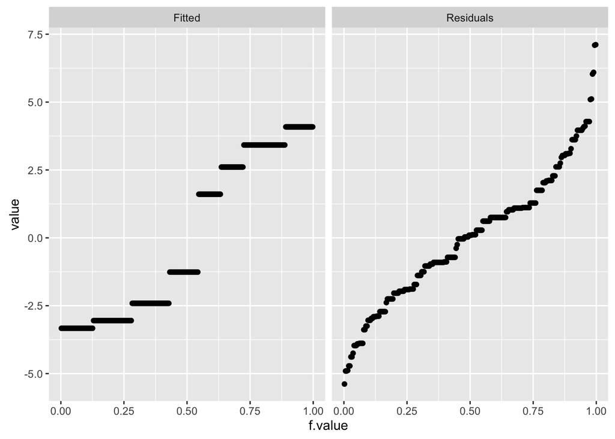

```r
ggplot(singer.fit.long, aes(x=f.value, y=value)) +
  geom_point() + facet_wrap(~type)
```

### Interlude: Tibbles

For large or complex data sets, *tibbles* are a minor improvement on data frames:

- They print more elegantly;
- They subset more predictably. e.g. When you use square brackets to subset a tibble, you always get another tibble. (With data frames you might get a vector or a data frame.)

Generally though you can use them in all the same ways as you use data frames.

Let’s read in a .csv file on lengths of Billboard Hot 100 song s in 2000:

```r
billboard.raw = read.csv("https://github.com/hadley/tidy-data/raw/master/data/billboard.csv", stringsAsFactors = FALSE)
```

To turn this into a tibble, we use the `tbl_df()` function in the `dplyr` library.

```r
library(dplyr)
billboard = tbl_df(billboard.raw)
```

The object `billboard` displays reasonably elegantly:

```r
billboard
```

```
## # A tibble: 317 × 83
##     year     artist.inverted                                 track  time
##    <int>               <chr>                                 <chr> <chr>
## 1   2000     Destiny's Child              Independent Women Part I  3:38
## 2   2000             Santana                          Maria, Maria  4:18
## 3   2000       Savage Garden                    I Knew I Loved You  4:07
## 4   2000             Madonna                                 Music  3:45
## 5   2000 Aguilera, Christina Come On Over Baby (All I Want Is You)  3:38
## 6   2000               Janet                 Doesn't Really Matter  4:17
## 7   2000     Destiny's Child                           Say My Name  4:31
## 8   2000   Iglesias, Enrique                           Be With You  3:36
## 9   2000               Sisqo                            Incomplete  3:52
## 10  2000            Lonestar                                Amazed  4:25
## # ... with 307 more rows, and 79 more variables: genre <chr>,
## #   date.entered <chr>, date.peaked <chr>, x1st.week <int>,
## #   x2nd.week <int>, x3rd.week <int>, x4th.week <int>, x5th.week <int>,
## #   x6th.week <int>, x7th.week <int>, x8th.week <int>, x9th.week <int>,
## #   x10th.week <int>, x11th.week <int>, x12th.week <int>,
## #   x13th.week <int>, x14th.week <int>, x15th.week <int>,
## #   x16th.week <int>, x17th.week <int>, x18th.week <int>,
## #   x19th.week <int>, x20th.week <int>, x21st.week <int>,
## #   x22nd.week <int>, x23rd.week <int>, x24th.week <int>,
## #   x25th.week <int>, x26th.week <int>, x27th.week <int>,
## #   x28th.week <int>, x29th.week <int>, x30th.week <int>,
## #   x31st.week <int>, x32nd.week <int>, x33rd.week <int>,
## #   x34th.week <int>, x35th.week <int>, x36th.week <int>,
## #   x37th.week <int>, x38th.week <int>, x39th.week <int>,
## #   x40th.week <int>, x41st.week <int>, x42nd.week <int>,
## #   x43rd.week <int>, x44th.week <int>, x45th.week <int>,
## #   x46th.week <int>, x47th.week <int>, x48th.week <int>,
## #   x49th.week <int>, x50th.week <int>, x51st.week <int>,
## #   x52nd.week <int>, x53rd.week <int>, x54th.week <int>,
## #   x55th.week <int>, x56th.week <int>, x57th.week <int>,
## #   x58th.week <int>, x59th.week <int>, x60th.week <int>,
## #   x61st.week <int>, x62nd.week <int>, x63rd.week <int>,
## #   x64th.week <int>, x65th.week <int>, x66th.week <lgl>,
## #   x67th.week <lgl>, x68th.week <lgl>, x69th.week <lgl>,
## #   x70th.week <lgl>, x71st.week <lgl>, x72nd.week <lgl>,
## #   x73rd.week <lgl>, x74th.week <lgl>, x75th.week <lgl>, x76th.week <lgl>
```

### How long are songs?

How long were the songs on the 2000 Hot 100? We see from the tibble display that the `time` column of our tibble is a character variable instead of numeric. It’ll take some work to fix this.

The immediate problem is the colon. All we want are the numbers before (the minutes) and after (the seconds) the colon for each entry. The function `strsplit` splits the strings:

```r
billboard.time = strsplit(billboard$time, ":")
```

`billboard.time` is now a list. Now we need to:

- “unlist” `billboard.time` by making it into a matrix;
- extract the two columns of the matrix (minutes and seconds) and make them numeric;
- calculate the length of each song in seconds;
- change this to minutes (because minutes are more intuitive than seconds);
- replace the `time` column of `billboard.time` with this new numeric vector.

```r
billboard.time = matrix(unlist(billboard.time),
  byrow=T, ncol=2)
billboard.mins = as.numeric(billboard.time[,1])
billboard.secs = as.numeric(billboard.time[,2])
billboard.time = billboard.mins * 60 + billboard.secs
billboard$time = billboard.time / 60
```

Depending on what we want to do, it may be useful to have the data in long form as well as in wide form. We use `gather()`:

```r
billboard.long <- billboard %>% gather(week, rank, x1st.week:x76th.week, na.rm = TRUE)
billboard.long
```

```
## # A tibble: 5,307 × 9
##     year     artist.inverted                                 track
## *  <int>               <chr>                                 <chr>
## 1   2000     Destiny's Child              Independent Women Part I
## 2   2000             Santana                          Maria, Maria
## 3   2000       Savage Garden                    I Knew I Loved You
## 4   2000             Madonna                                 Music
## 5   2000 Aguilera, Christina Come On Over Baby (All I Want Is You)
## 6   2000               Janet                 Doesn't Really Matter
## 7   2000     Destiny's Child                           Say My Name
## 8   2000   Iglesias, Enrique                           Be With You
## 9   2000               Sisqo                            Incomplete
## 10  2000            Lonestar                                Amazed
## # ... with 5,297 more rows, and 6 more variables: time <dbl>, genre <chr>,
## #   date.entered <chr>, date.peaked <chr>, week <chr>, rank <int>
```

Here `x1st.week:x76th.week` gathers all the columns from `x1st.week` to `x76th.week` and turns them into separate observations. Thus “Independent Women Part I” accounts for one observation in `billboard` but 28 observations in `billboard.long`, because it was on the charts for 28 weeks.

Let’s first go back to the wide form data. Using songs as the unit, here’s a histogram of song lengths:

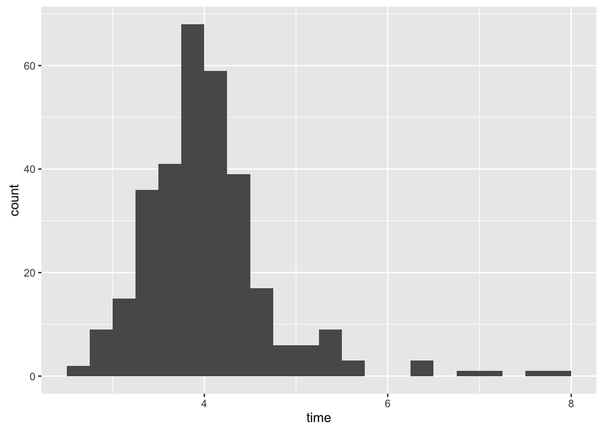

```r
ggplot(billboard, aes(x=time)) + geom_histogram(breaks=seq(2.5, 8, 0.25))
```

Compare this to a histogram using song-weeks as the unit:

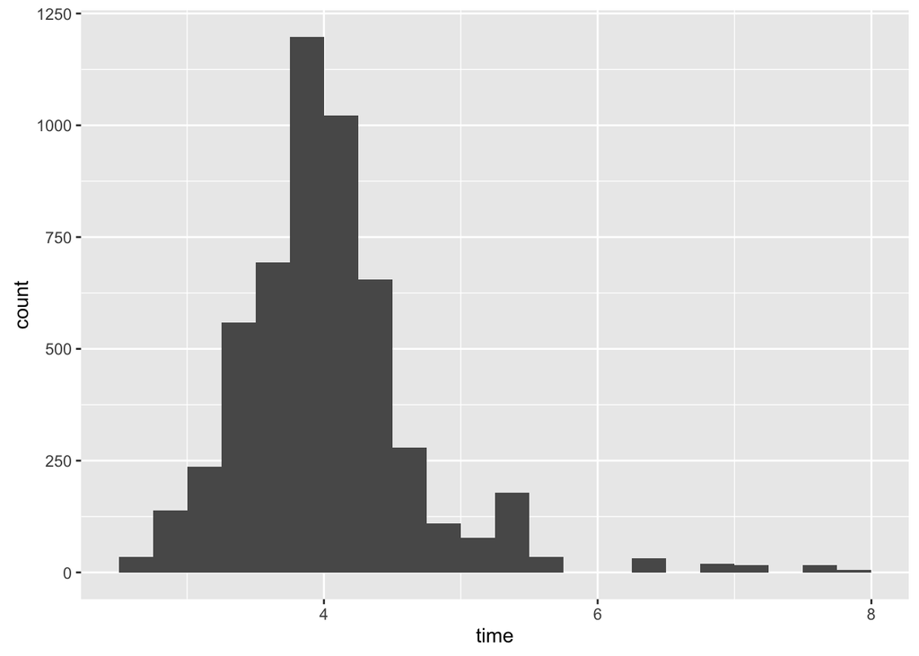

```r
ggplot(billboard.long, aes(x=time)) + geom_histogram(breaks=seq(2.5, 8, 0.25))
```

The $y$-axis scale has changed (since there are more observations.) However, the shape of the histogram is pretty much the same, suggesting that weighting by number of weeks on the chart doesn’t make much difference.

Let’s facet by chart position. To avoid drawing 100 graphs, we use `subset()` to only consider the top 10 chart positions:

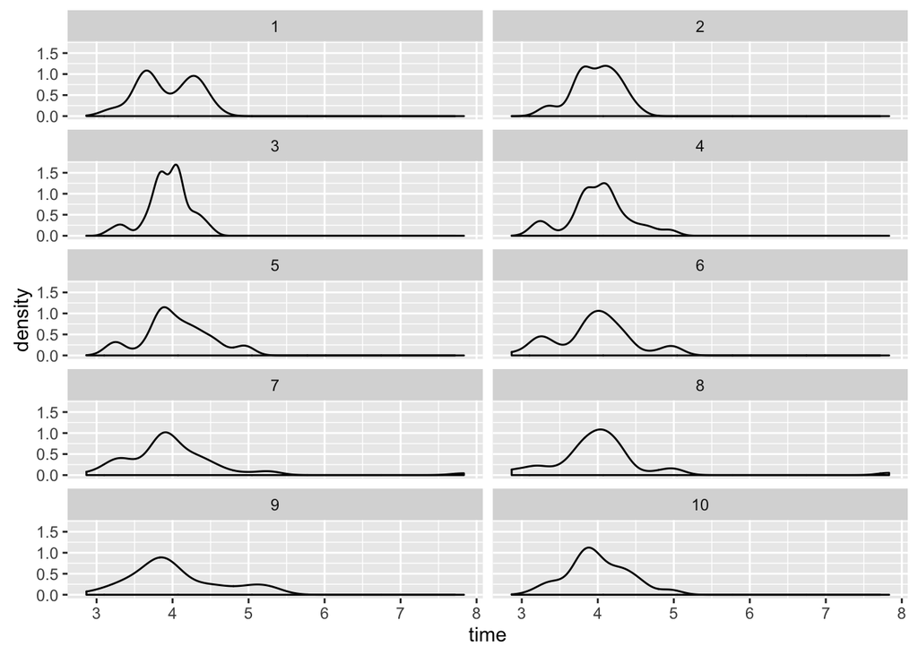

```r
ggplot(subset(billboard.long, rank <= 10), aes(x=time)) + geom_density() + facet_wrap(~rank, ncol=2)
```

I drew density plots instead of histograms because of the small samples. It’s a bit hard to tell here whether the differences are systematic or noise.

Finally, let’s find mean song length by chart position.

```r
time.means = aggregate(time~rank, FUN=mean, data=billboard.long)
```

Rank is numeric, so it makes sense to draw a **line graph** using `geom_line()`:

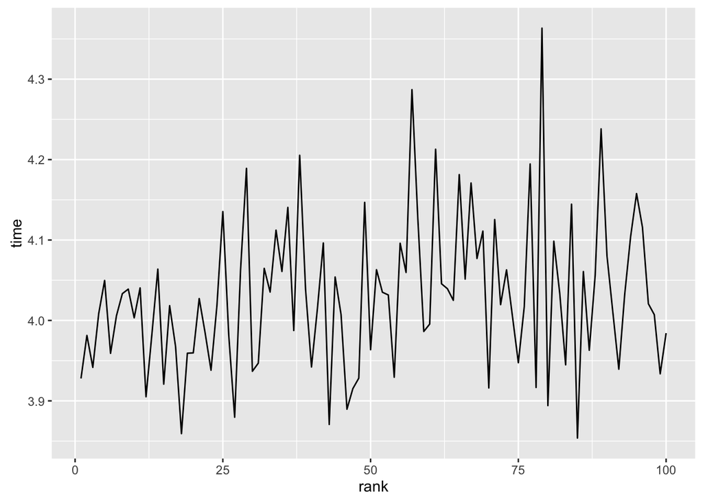

```r
ggplot(time.means, aes(x=rank, y=time)) +
  geom_line()
```

There’s still a lot of noise. (Later on we’ll learn a bit about *smoothing*, which would help a lot here.) The one thing that seems apparent is the high ranks are noisier than low ranks. But that’s just because the low ranks often have the same song appearing repeatedly (songs often stay in the top ten for ages, whilst they rarely stay in the nineties for more than a week.)